# Cox model

## The Cox *proportional hazards* model (CPHM)

\(h(t) \quad = \quad h_0(t) \quad e\ ^{\ \beta_1 x_1 + \ \beta_2 x_2 + ...+ \ \beta_k x_k} \quad = \quad h_0(t) \quad e\ ^{\beta_1 x_1} \ e\ ^{\beta_2 x_2} \ ... \ e\ ^{\beta_k x_k}\)

Models the *hazard function* \(h(t) = \frac{f(t)}{S(t)} = - \frac{d \log S(t)}{d t}\), the instantaneous *hazard* of event at time \(t\)

\(h_0(t)\) is the baseline hazard (i.e., when all \(x\)’s are 0)

\(e\ ^{\beta}\) are *hazard ratios*; suppose \(x_1\) is an indicator (i.e., 0 or 1); then

- \(h(t|x_1=1) \quad = \quad h_0(t) \quad e\ ^{\beta_1} \quad e\ ^{\beta_2 x_2} \quad ... \quad e\ ^{\beta_k x_k}\)
- \(h(t|x_1=0) \quad = \quad h_0(t) \quad 1 \qquad e\ ^{\beta_2 x_2} \quad ... \quad e\ ^{\beta_k x_k}\)

So that

- \(\frac{h(t|x_1=1)}{h(t|x_1=0)} = e\ ^{\beta_1}\)

So, it is implicitely assumed that the *hazard ratio* for *any time t* is a constant, which does not depend on \(t\)

## Data prep

```r
library(tidyverse)
library(survival)
d <- lung %>%
  mutate(status = factor(status,
                         levels = 1:2,
                         labels = c("censored", "dead")),
         sex = factor(sex,
                      levels = 1:2,
                      labels = c("male", "female")))
head(d)
```

```
  inst time   status age  sex ph.ecog ph.karno pat.karno meal.cal wt.loss
1    3  306     dead  74 male       1       90       100     1175      NA
2    3  455     dead  68 male       0       90        90     1225      15
3    3 1010 censored  56 male       0       90        90       NA      15
4    5  210     dead  57 male       1       90        60     1150      11
5    1  883     dead  60 male       0      100        90       NA       0
6   12 1022 censored  74 male       1       50        80      513       0
```

## Fitting a CPH model

Function `coxph()` fits CPH models

```r
fit <- coxph(Surv(time, status == "dead") ~ sex, data = d)
fit
```

```
Call:
coxph(formula = Surv(time, status == "dead") ~ sex, data = d)

             coef exp(coef) se(coef)      z       p
sexfemale -0.5310    0.5880   0.1672 -3.176 0.00149

Likelihood ratio test=10.63  on 1 df, p=0.001111
n= 228, number of events= 165
```

Assumptions:

- Non-informative censoring
- Proportional hazards

## Hazard Ratios (HR)

Exponentiate the model coefficients (and CI) to get HR (and CI)

```r
coef(fit)           # gets model coefficients
```

```
 sexfemale
-0.5310235
```

```r
exp(coef(fit))      # gets the HR
```

```
sexfemale
0.5880028
```

```r
exp(confint(fit))   # gets the 95% CI for HR
```

```
              2.5 %    97.5 %
sexfemale 0.4237178 0.8159848
```

## A model with three variables

```r
fit <- coxph(Surv(time, status == "dead") ~ age + sex + ph.ecog, data = d)
fit
```

```
Call:
coxph(formula = Surv(time, status == "dead") ~ age + sex + ph.ecog,
    data = d)

               coef exp(coef)  se(coef)      z        p
age        0.011067  1.011128  0.009267  1.194 0.232416
sexfemale -0.552612  0.575445  0.167739 -3.294 0.000986
ph.ecog    0.463728  1.589991  0.113577  4.083 4.45e-05

Likelihood ratio test=30.5  on 3 df, p=1.083e-06
n= 227, number of events= 164
   (1 observation deleted due to missingness)
```

```r
exp(coef(fit))                    # to get hazard ratios (HR)
```

```
      age sexfemale   ph.ecog
1.0111282 0.5754446 1.5899912
```

## Plotting HR

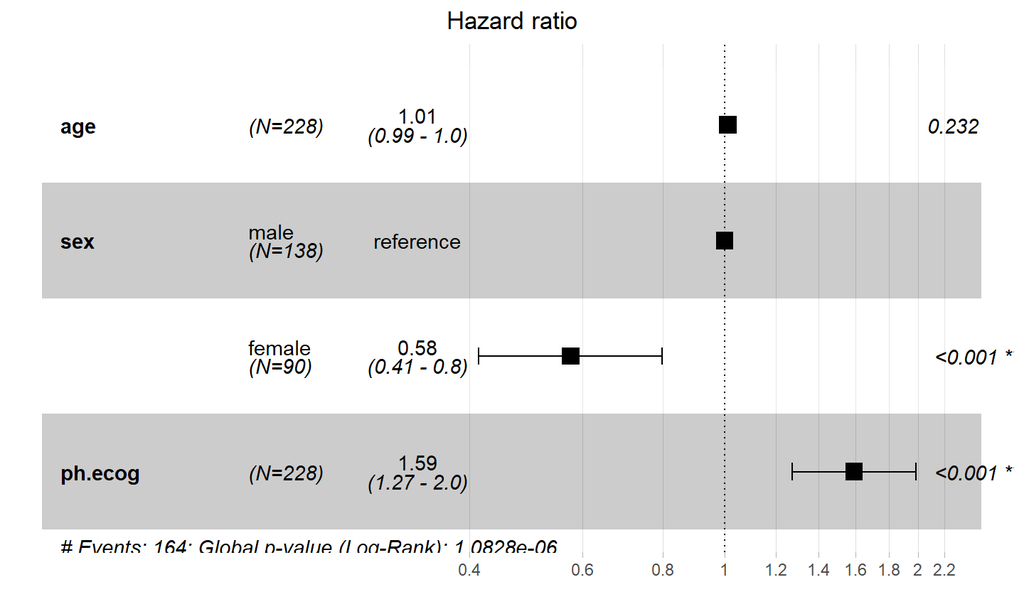

```r
survminer::ggforest(fit, data = d, fontsize = 1)
```

## A better plot

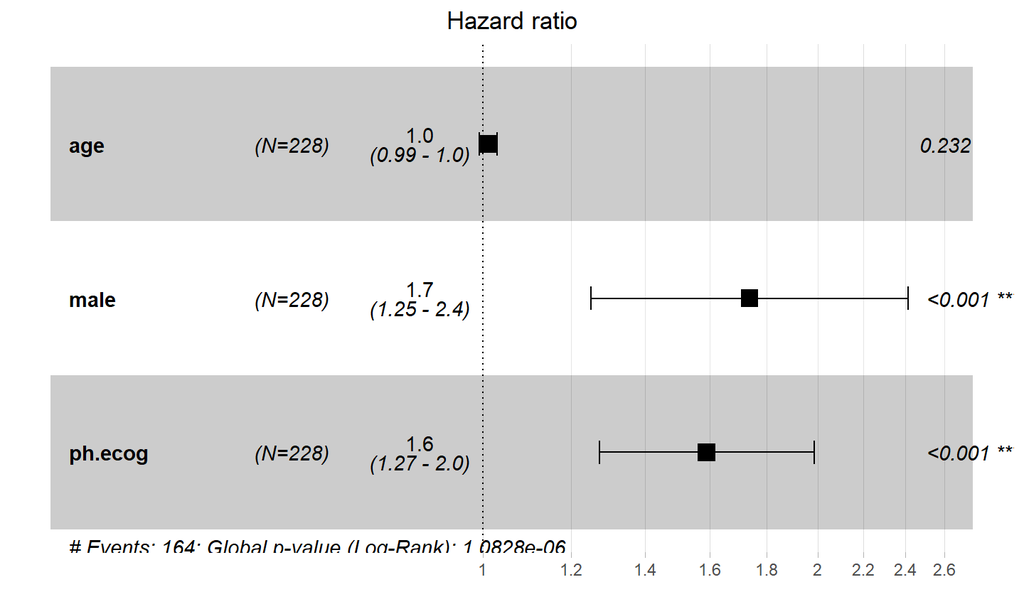

```r
d$male <- as.numeric(d$sex == "male")
fit <- coxph(Surv(time, status == "dead") ~ age + male + ph.ecog, data = d)
survminer::ggforest(fit, data = d, fontsize = 1)
```

## Assessing the PH assumption

A test for deviation from proportional hazards can be done with function `cox.zph`

```r
cox.zph(fit)
```

```
        chisq df    p
age     0.188  1 0.66
male    2.305  1 0.13
ph.ecog 2.054  1 0.15
GLOBAL  4.464  3 0.22
```

A significant p-value means evidence of deviation from proportional hazards.

Fore more thorough ways of assessing assumptions of the Cox PH model, see [this](https://www.r-bloggers.com/cox-model-assumptions/)

When PH do not hold, [Accelerated Failure Time (AFT) models](https://pubmed.ncbi.nlm.nih.gov/17080754/) may be used.

## Exercise

Prepare the `ovarian` data as in the previous exercise.

1. Fit a Cox PH model with treatment group, residual disease, age group, and ECOG performance status as covariates.
2. Plot the HR from this model fit
3. Verify the PH assumption in this model fit